# Project 1: Wrangling, Exploration, Visualization

SDS322E - Kelsey Garcia kg29435

10/26/2021

## 0. Introduction

##### Now that we’re in a world highly obsessed with the internet and overall perceived happiness, as well as in the midst of one of the greatest suicide rates in history, I thought it would be interesting to study actual data over a 10-year period on all three of these topics. Three datasets were used, all from gapminder.org where each individual dataset contained a different set of information concerning the three variables of internet use, happiness score, and total suicides. The internet users data represents the percentage of the population in each country in a given year that uses the internet. The happiness score data was collected by questionnaire’s and manipulated to represent the percentage of happiness the reporting individuals felt. These results were averaged over each country and over each year from 2005 to 2015. Lastly, the total suicides data represented the number of deaths caused by self-inflicted injury for each country across each of the aforementioned years. Prior to actually performing the analysis, I wanted to see if there was a negative correlation with internet use and happiness score, meaning that countries that the internet more tended to be less happy. I also expected to see a positive correlation between happiness score and total suicides meaning that generally happier countries tend to have fewer deaths by suicide. However, it’s important to note that this data does not analyze many confounding variables such as quality of life in each country and individual causes of mental illness.

## 1. Tidying: Rearranging Wide/Long

##### Each dataset was pivoted longer prior to merging so that the values for the three variables anlyzed were each given their own column and the year was also given its own column.

#### *Tidying the ‘internet_users’ dataset*

```r
internet_users <- select(internet_users, -('1959':'2004'),-('2016':'2018'))
head(internet_users)
```

```
## # A tibble: 6 x 12
##   country `2005` `2006` `2007` `2008` `2009` `2010` `2011` `2012` `2013` `2014`
##   <chr>    <dbl>  <dbl>  <dbl>  <dbl>  <dbl>  <dbl>  <dbl>  <dbl>  <dbl>  <dbl>
## 1 Aruba    28      30.9  52     58      62     69    74      78.9   83.8  88.7
## 2 Afghan…   2.11    1.9   1.84   3.55    4      5     5.45    5.9    7     8.26
## 3 Angola    1.5     1.7   1.9    2.3     2.8    3.1   6.5     8.9   21.4  12.4
## 4 Albania   9.61   15    23.9   41.2    45     49    54.7    57.2   60.1  63.3
## 5 Andorra  48.9    70.9  70     78.5    81     81    86.4    94     95.9  96.9
## 6 United…  52      61    63     64      68     78    85      88     90.4  90.5
## # … with 1 more variable: `2015` <dbl>
```

```r
internet_users_long<-internet_users %>%
                      pivot_longer(2:12, names_to="year", values_to="internet_users")
head(internet_users_long)
```

```
## # A tibble: 6 x 3
##   country year  internet_users
##   <chr>   <chr>          <dbl>
## 1 Aruba   2005            28
## 2 Aruba   2006            30.9
## 3 Aruba   2007            52
## 4 Aruba   2008            58
## 5 Aruba   2009            62
## 6 Aruba   2010            69
```

#### *Tidying the ’happy_whr’dataset*

```r
happy_whr <- select(happy_whr, -('2004'),-('2016':'2018'))
head(happy_whr)
```

```
## # A tibble: 6 x 12
##   country `2005` `2006` `2007` `2008` `2009` `2010` `2011` `2012` `2013` `2014`
##   <chr>    <dbl>  <dbl>  <dbl>  <dbl>  <dbl>  <dbl>  <dbl>  <dbl>  <dbl>  <dbl>
## 1 Afghan…   NA     NA     37.2   44     47.6   38.3   37.8   35.7   31.3   39.8
## 2 Angola    NA     NA     NA     NA     NA     55.9   43.6   39.4   37.9   NA
## 3 Albania   NA     46.3   NA     54.9   52.7   58.7   55.1   45.5   48.1   46.1
## 4 United…   67.3   NA     NA     68.7   71     71.2   72.2   66.2   65.4   65.7
## 5 Argent…   63.1   60.7   59.6   64.2   64.4   67.8   64.7   65.8   66.7   67
## 6 Armenia   42.9   48.8   46.5   41.8   43.7   42.6   43.2   42.8   44.5   43.5
## # … with 1 more variable: `2015` <dbl>
```

```r
happy_whr_long <- happy_whr %>%
                  pivot_longer(2:12, names_to="year", values_to="happiness_score")
head(happy_whr_long)
```

```
## # A tibble: 6 x 3
##   country     year  happiness_score
##   <chr>       <chr>           <dbl>
## 1 Afghanistan 2005             NA
## 2 Afghanistan 2006             NA
## 3 Afghanistan 2007             37.2
## 4 Afghanistan 2008             44
## 5 Afghanistan 2009             47.6
## 6 Afghanistan 2010             38.3
```

#### *Tidying the ‘suicide_total’ score*

```r
suicide_total <- select(suicide_total,-('1989':'2004'))
head(suicide_total)
```

```
## # A tibble: 6 x 12
##   country `2005` `2006` `2007` `2008` `2009` `2010` `2011` `2012` `2013` `2014`
##   <chr>   <chr>  <chr>  <chr>  <chr>  <chr>  <chr>  <chr>  <chr>  <chr>  <chr>
## 1 Afghan… 1650   1680   1710   1750   1760   1810   1870   1990   2080   2170
## 2 Angola  1010   1040   1060   1080   1100   1120   1140   1170   1200   1220
## 3 Albania 204    204    205    201    195    191    188    186    184    183
## 4 Andorra 7.19   7.39   7.53   7.67   7.76   7.85   7.92   7.97   7.72   7.78
## 5 United… 293    347    312    358    399    423    436    443    445    446
## 6 Argent… 4490   4560   4610   4640   4650   4700   4800   4920   5010   5010
## # … with 1 more variable: `2015` <chr>
```

```r
suicide_total_long <- suicide_total %>%
                      pivot_longer(2:12, names_to="year", values_to="total_suicides")
head(suicide_total_long)
```

```
## # A tibble: 6 x 3
##   country     year  total_suicides
##   <chr>       <chr> <chr>
## 1 Afghanistan 2005  1650
## 2 Afghanistan 2006  1680
## 3 Afghanistan 2007  1710
## 4 Afghanistan 2008  1750
## 5 Afghanistan 2009  1760
## 6 Afghanistan 2010  1810
```

```r
## changing the "k"'s in total suicide values (ex/ 41k) to numeric values
suicide_total_long <- suicide_total_long %>% mutate(total_suicides=str_replace(total_suicides, "k","000")) %>% mutate(total_suicides=str_replace(total_suicides,"\\.","")) %>%  mutate(total_suicides= as.numeric(total_suicides))
suicide_total_long %>% filter(country=="United States") %>% head()
```

```
## # A tibble: 6 x 3
##   country       year  total_suicides
##   <chr>         <chr>          <dbl>
## 1 United States 2005          397000
## 2 United States 2006          404000
## 3 United States 2007           41000
## 4 United States 2008          416000
## 5 United States 2009          423000
## 6 United States 2010          431000
```

## 2. Joining/Merging

#### Relevant data information prior to merging

#### *The distinct country IDs for ‘internet_users_long’*

##### The ‘internet_users_long’ dataset has 51 countries distinct from the ‘happy_whr_long’ and 20 countries in its data distinct from ‘suicide_total_long’. Many of the countries unique to the ‘internet_users_long’ dataset are located amongst the Pacific and the Carribbean islands.

```r
## number of unique IDs from 'happy_whr_long'
anti_join(internet_users_long, happy_whr_long, by=c("country","year")) %>% summarize(n_distinct(country))
```

```
## # A tibble: 1 x 1
##   `n_distinct(country)`
##                   <int>
## 1                    51
```

```r
## what those unique IDs are compared to 'happy_whr_long'
anti_join(internet_users_long, happy_whr_long, by=c("country","year"))
```

```
## # A tibble: 561 x 3
##    country year  internet_users
##    <chr>   <chr>          <dbl>
##  1 Aruba   2005            28
##  2 Aruba   2006            30.9
##  3 Aruba   2007            52
##  4 Aruba   2008            58
##  5 Aruba   2009            62
##  6 Aruba   2010            69
##  7 Aruba   2011            74
##  8 Aruba   2012            78.9
##  9 Aruba   2013            83.8
## 10 Aruba   2014            88.7
## # … with 551 more rows
```

```r
## number of unique IDs form 'suicide_total_long'
anti_join(internet_users_long, suicide_total_long, by=c("country","year")) %>% summarize(n_distinct(country))
```

```
## # A tibble: 1 x 1
##   `n_distinct(country)`
##                   <int>
## 1                    20
```

```r
## what those unique IDs are compared to 'suicide_total_long'
anti_join(internet_users_long, suicide_total_long, by=c("country","year"))
```

```
## # A tibble: 220 x 3
##    country year  internet_users
##    <chr>   <chr>          <dbl>
##  1 Aruba   2005            28
##  2 Aruba   2006            30.9
##  3 Aruba   2007            52
##  4 Aruba   2008            58
##  5 Aruba   2009            62
##  6 Aruba   2010            69
##  7 Aruba   2011            74
##  8 Aruba   2012            78.9
##  9 Aruba   2013            83.8
## 10 Aruba   2014            88.7
## # … with 210 more rows
```

#### *The distinct country IDs for ‘happy_whr_long’*

##### The ‘happy_whr_long’ dataset has 1 country distinct from the ‘internet_users_long’ dataset and 1 country in its data distinct from ‘suicide_total_long’. ‘happy_whr_long’ has Taiwan included in its data when ‘internet_users_long’ doesn’t and Hong Kong, China in its data when ‘suicide_total_long’ doesn’t.

```r
## number of unique IDs from 'internet_users_long'
anti_join(happy_whr_long, internet_users_long, by=c("country","year")) %>% summarize(n_distinct(country))
```

```
## # A tibble: 1 x 1
##   `n_distinct(country)`
##                   <int>
## 1                     1
```

```r
## what those unique IDs compared to 'internet_users_long'
anti_join(happy_whr_long, internet_users_long, by=c("country","year"))
```

```
## # A tibble: 11 x 3
##    country year  happiness_score
##    <chr>   <chr>           <dbl>
##  1 Taiwan  2005             61.9
##  2 Taiwan  2006             NA
##  3 Taiwan  2007             55.5
##  4 Taiwan  2008             NA
##  5 Taiwan  2009             62.3
##  6 Taiwan  2010             63.1
##  7 Taiwan  2011             61.3
##  8 Taiwan  2012             63.4
##  9 Taiwan  2013             63.6
## 10 Taiwan  2014             64.5
## 11 Taiwan  2015             65.1
```

```r
## number of unique IDs from 'suicide_total_long'
anti_join(happy_whr_long, suicide_total_long, by=c("country","year")) %>% summarize(n_distinct(country))
```

```
## # A tibble: 1 x 1
##   `n_distinct(country)`
##                   <int>
## 1                     1
```

```r
## what those unique IDs are compared to 'suicide_total_long'
anti_join(happy_whr_long, suicide_total_long, by=c("country","year"))
```

```
## # A tibble: 11 x 3
##    country          year  happiness_score
##    <chr>            <chr>           <dbl>
##  1 Hong Kong, China 2005             55.1
##  2 Hong Kong, China 2006             NA
##  3 Hong Kong, China 2007             51.4
##  4 Hong Kong, China 2008             54
##  5 Hong Kong, China 2009             56.4
##  6 Hong Kong, China 2010             54.7
##  7 Hong Kong, China 2011             54.8
##  8 Hong Kong, China 2012             NA
##  9 Hong Kong, China 2013             54.6
## 10 Hong Kong, China 2014             NA
## 11 Hong Kong, China 2015             55
```

#### *The distinct country IDs for ‘suicide_total_long’*

##### The ‘suicide_total_long’ dataset has 1 country distinct from the ‘internet_users_long’ dataset and 32 countries in its data distinct from ‘happy_whr_long’. ‘suicide_total_long’ also has Taiwan as a unique country that the ‘internet_users_long’ dataset doesn’t contain. Again, many of the countries unique to the ‘suicide_total_long’ dataset not found in the ‘happy_whr_long’ dataset are located amongst the Pacific and the Carribbean islands.

```r
## number of unique IDs from 'internet_user_long'
anti_join(suicide_total_long, internet_users_long, by=c("country","year")) %>% summarize(n_distinct(country))
```

```
## # A tibble: 1 x 1
##   `n_distinct(country)`
##                   <int>
## 1                     1
```

```r
## what those unique IDs compared to 'internet_users_long'
anti_join(suicide_total_long, internet_users_long, by=c("country","year"))
```

```
## # A tibble: 11 x 3
##    country year  total_suicides
##    <chr>   <chr>          <dbl>
##  1 Taiwan  2005            3950
##  2 Taiwan  2006            3960
##  3 Taiwan  2007            3920
##  4 Taiwan  2008            3900
##  5 Taiwan  2009            3920
##  6 Taiwan  2010            3930
##  7 Taiwan  2011            3930
##  8 Taiwan  2012            3900
##  9 Taiwan  2013            3920
## 10 Taiwan  2014            3990
## 11 Taiwan  2015            4050
```

```r
## number of unique IDs from 'happy_whr_long'
anti_join(suicide_total_long, happy_whr_long, by=c("country","year")) %>% summarize(n_distinct(country))
```

```
## # A tibble: 1 x 1
##   `n_distinct(country)`
##                   <int>
## 1                    32
```

```r
## what those unique IDs are compared to 'happy_whr_long'
anti_join(suicide_total_long, happy_whr_long, by=c("country","year"))
```

```
## # A tibble: 352 x 3
##    country year  total_suicides
##    <chr>   <chr>          <dbl>
##  1 Andorra 2005             719
##  2 Andorra 2006             739
##  3 Andorra 2007             753
##  4 Andorra 2008             767
##  5 Andorra 2009             776
##  6 Andorra 2010             785
##  7 Andorra 2011             792
##  8 Andorra 2012             797
##  9 Andorra 2013             772
## 10 Andorra 2014             778
## # … with 342 more rows
```

#### Joining ‘internet_users_long’,‘happy_whr_long’, and ‘suicide_total_long’ together for data analysis

##### Based on the information on unique country IDs for each dataset it will be most effective to perform two inner joins to only obtain and analyze countries that have information for all three of the different variables in question. The inner join is effective for that because it only includes observations that are shared by any two datasets being joined. Each dataset was joined to another by their shared country and year variables. There were 161 country IDs in common between all three datasets.

##### A full join was performed to calculate the number of observations lost from performing an inner join versus a full join which was found to be 2,376 country & year observations in total(4,147 observations in the full join and 1,771 observations in the inner join). The ‘internet_users_long’ dataset originally had 2,343 observations, ‘happy_whr_long’ had 1,793 observations, and ‘suicide_total_long’ had 2,134 observatoins.

```r
# stepwise joining of the three datasets
partialjoin <- inner_join(internet_users_long, happy_whr_long, by=c("country","year"))

completejoin <- inner_join(partialjoin, suicide_total_long,by=c("country","year"))

head(completejoin)
```

```
## # A tibble: 6 x 5
##   country     year  internet_users happiness_score total_suicides
##   <chr>       <chr>          <dbl>           <dbl>          <dbl>
## 1 Afghanistan 2005            2.11            NA             1650
## 2 Afghanistan 2006            1.9             NA             1680
## 3 Afghanistan 2007            1.84            37.2           1710
## 4 Afghanistan 2008            3.55            44             1750
## 5 Afghanistan 2009            4               47.6           1760
## 6 Afghanistan 2010            5               38.3           1810
```

```r
# total number of observations/rows - \1,771 observations\
str(completejoin)
```

```
## tibble [1,771 × 5] (S3: tbl_df/tbl/data.frame)
##  $ country        : chr [1:1771] "Afghanistan" "Afghanistan" "Afghanistan" "Afghanistan" ...
##  $ year           : chr [1:1771] "2005" "2006" "2007" "2008" ...
##  $ internet_users : num [1:1771] 2.11 1.9 1.84 3.55 4 5 5.45 5.9 7 8.26 ...
##  $ happiness_score: num [1:1771] NA NA 37.2 44 47.6 38.3 37.8 35.7 31.3 39.8 ...
##  $ total_suicides : num [1:1771] 1650 1680 1710 1750 1760 1810 1870 1990 2080 2170 ...
```

```r
# number of id variables in common between all three datasets - \161 countries\
completejoin %>% summarize(n_distinct(country))
```

```
## # A tibble: 1 x 1
##   `n_distinct(country)`
##                   <int>
## 1                   161
```

```r
# what country IDs are shared by all three datasets
completejoin %>% count(country)
```

```
## # A tibble: 161 x 2
##    country         n
##    <chr>       <int>
##  1 Afghanistan    11
##  2 Albania        11
##  3 Algeria        11
##  4 Angola         11
##  5 Argentina      11
##  6 Armenia        11
##  7 Australia      11
##  8 Austria        11
##  9 Azerbaijan     11
## 10 Bahrain        11
## # … with 151 more rows
```

```r
# number of observations lost when removing the unique country IDs associated with the various data sets
partialfjoin <- full_join(internet_users_long, happy_whr_long, by=c("country"="year"))

full_join(partialfjoin, suicide_total_long, by=c("country","year")) # gives 4,147 observations
```

```
## # A tibble: 4,147 x 6
##    country year  internet_users country.y happiness_score total_suicides
##    <chr>   <chr>          <dbl> <chr>               <dbl>          <dbl>
##  1 Aruba   2005            28   <NA>                   NA             NA
##  2 Aruba   2006            30.9 <NA>                   NA             NA
##  3 Aruba   2007            52   <NA>                   NA             NA
##  4 Aruba   2008            58   <NA>                   NA             NA
##  5 Aruba   2009            62   <NA>                   NA             NA
##  6 Aruba   2010            69   <NA>                   NA             NA
##  7 Aruba   2011            74   <NA>                   NA             NA
##  8 Aruba   2012            78.9 <NA>                   NA             NA
##  9 Aruba   2013            83.8 <NA>                   NA             NA
## 10 Aruba   2014            88.7 <NA>                   NA             NA
## # … with 4,137 more rows
```

```r
4147-1771 # a loss of 2,376 observations
```

```
## [1] 2376
```

## 3. Wrangling

#### *Creating a new variable of the percent change in internet use in the US from one year to the next*

```r
completejoin %>%
  filter(country=="United States") %>%
  mutate(pct_change_internet_use = (internet_users-lag(internet_users)) / lag(internet_users))
```

```
## # A tibble: 11 x 6
##    country  year  internet_users happiness_score total_suicides pct_change_inte…
##    <chr>    <chr>          <dbl>           <dbl>          <dbl>            <dbl>
##  1 United … 2005            68.9            71.8         397000         NA
##  2 United … 2006            75              75.1         404000          0.0885
##  3 United … 2007            74              72.8          41000         -0.0133
##  4 United … 2008            71              71.6         416000         -0.0405
##  5 United … 2009            71.7            71.6         423000          0.00986
##  6 United … 2010            69.7            71.2         431000         -0.0279
##  7 United … 2011            74.7            70.3         439000          0.0717
##  8 United … 2012            71.4            72.5         447000         -0.0442
##  9 United … 2013            73              71.5         456000          0.0224
## 10 United … 2014            74.6            68.6         463000          0.0219
## 11 United … 2015            85.5            68           466000          0.146
```

#### *Summary statistics on categorical variables*

##### Each of the 161 country IDs was observed 11 times (from the years 2005-2015). Each year was observed 161 times, once for each country.

```r
## obtaining counts of observations for each country ID
completejoin %>% group_by(country) %>% summarize(n())
```

```
## # A tibble: 161 x 2
##    country     `n()`
##    <chr>       <int>
##  1 Afghanistan    11
##  2 Albania        11
##  3 Algeria        11
##  4 Angola         11
##  5 Argentina      11
##  6 Armenia        11
##  7 Australia      11
##  8 Austria        11
##  9 Azerbaijan     11
## 10 Bahrain        11
## # … with 151 more rows
```

```r
## obtaining counts of observations in each year
completejoin %>% group_by(year) %>% summarize(n())
```

```
## # A tibble: 11 x 2
##    year  `n()`
##    <chr> <int>
##  1 2005    161
##  2 2006    161
##  3 2007    161
##  4 2008    161
##  5 2009    161
##  6 2010    161
##  7 2011    161
##  8 2012    161
##  9 2013    161
## 10 2014    161
## 11 2015    161
```

```r
## obtaining counts of observations of each combination of country ID and year
completejoin %>% group_by(country,year) %>% summarize(n())
```

```
## # A tibble: 1,771 x 3
## # Groups:   country [161]
##    country     year  `n()`
##    <chr>       <chr> <int>
##  1 Afghanistan 2005      1
##  2 Afghanistan 2006      1
##  3 Afghanistan 2007      1
##  4 Afghanistan 2008      1
##  5 Afghanistan 2009      1
##  6 Afghanistan 2010      1
##  7 Afghanistan 2011      1
##  8 Afghanistan 2012      1
##  9 Afghanistan 2013      1
## 10 Afghanistan 2014      1
## # … with 1,761 more rows
```

#### *Overall (ungrouped) summary statistics for numeric variables*

##### The average percent of the population that uses internet was found to be about 35% with a range from 0.182% to 98.2% of a country’s population using the internet. The average happiness score amongst all countries was 54.02. In other words, people tend to rate their happiness as being about the middle of the scale, not too poor but not too great. The mean of the total suicides in any country was 15,150 but the median was 879 meaning that a smaller number of countries with really high suicide counts pulled up the mean. There were also 18 NA’s found for the ‘internet_users’ data and 409 NA’s found for the ‘happiness_score’ data.

```r
## overall summary statistics for 'internet_users' variable
completejoin %>% summarize(mean_internet_users=mean(internet_users,na.rm=T),
                           sd_internet_users=sd(internet_users,na.rm=T),
                           med_internet_users=median(internet_users,na.rm=T),
                            min_internet_users=min(internet_users,na.rm=T),
                              max_internet_users=max(internet_users,na.rm=T))
```

```
## # A tibble: 1 x 5
##   mean_internet_u… sd_internet_use… med_internet_us… min_internet_us…
##              <dbl>            <dbl>            <dbl>            <dbl>
## 1             35.8             28.9               29            0.182
## # … with 1 more variable: max_internet_users <dbl>
```

```r
## overall summary statistics for 'happiness_score' variable
completejoin %>% summarize(mean_happiness_score=mean(happiness_score,na.rm=T),
                           sd_happiness_score=sd(happiness_score,na.rm=T),
                            med_happiness_score=median(happiness_score,na.rm=T),
                            min_happiness_score=min(happiness_score,na.rm=T),
                              max_happiness_score=max(happiness_score,na.rm=T))
```

```
## # A tibble: 1 x 5
##   mean_happiness_… sd_happiness_sc… med_happiness_s… min_happiness_s…
##              <dbl>            <dbl>            <dbl>            <dbl>
## 1             54.0             11.3             52.8             26.9
## # … with 1 more variable: max_happiness_score <dbl>
```

```r
## overall summary statistics for 'total_suicides' variable
completejoin %>% summarize(mean_total_suicides=mean(total_suicides,na.rm=T),
                           sd_total_suicides=sd(total_suicides,na.rm=T),
                            med_total_suicides=median(total_suicides,na.rm=T),
                            min_total_suicides=min(total_suicides,na.rm=T),
                              max_total_suicides=max(total_suicides,na.rm=T))
```

```
## # A tibble: 1 x 5
##   mean_total_suic… sd_total_suicid… med_total_suici… min_total_suici…
##              <dbl>            <dbl>            <dbl>            <dbl>
## 1           15150.           64078.              879               38
## # … with 1 more variable: max_total_suicides <dbl>
```

```r
## number of NAs for each variable
completejoin %>% summarize_all(function(x)sum(is.na(x)))
```

```
## # A tibble: 1 x 5
##   country  year internet_users happiness_score total_suicides
##     <int> <int>          <int>           <int>          <int>
## 1       0     0             18             409              0
```

#### *Summary statistics for numeric variables grouped by ‘country’*

##### The data for each country across all 11 years observed was analyzed to find the mean, standard deviation, median, maximum, and minimum for all three variables. The happiness score data, specifically, was further analyzed and arranged to identify the top 10 happiest countries in the dataset.

```r
## obtaining 2 of 5 summary statistics & showing an example of pivoting wider
groupedsummarystats <- completejoin %>% group_by(country) %>%
                      summarize(mean_internet_users=mean(internet_users,na.rm=T),
                           sd_internet_users=sd(internet_users,na.rm=T),
                           med_internet_users=median(internet_users,na.rm=T),
                            min_internet_users=min(internet_users,na.rm=T),
                              max_internet_users=max(internet_users,na.rm=T),
                           mean_happiness_score=mean(happiness_score,na.rm=T),
                           sd_happiness_score=sd(happiness_score,na.rm=T),
                            med_happiness_score=median(happiness_score,na.rm=T),
                            min_happiness_score=min(happiness_score,na.rm=T),
                              max_happiness_score=max(happiness_score,na.rm=T),
                           mean_total_suicides=mean(total_suicides,na.rm=T),
                           sd_total_suicides=sd(total_suicides,na.rm=T),
                            med_total_suicides=median(total_suicides,na.rm=T),
                            min_total_suicides=min(total_suicides,na.rm=T),
                              max_total_suicides=max(total_suicides,na.rm=T))
head(groupedsummarystats)
```

```
## # A tibble: 6 x 16
##   country mean_internet_u… sd_internet_use… med_internet_us… min_internet_us…
##   <chr>              <dbl>            <dbl>            <dbl>            <dbl>
## 1 Afghan…             4.50             2.22              4.5             1.84
## 2 Albania            44.1             19.7              49               9.61
## 3 Algeria            19.7             12.2              14.9             7.38
## 4 Angola              6.86             6.45              3.1             1.5
## 5 Argent…            47.7             18.0              51              20.9
## 6 Armenia            31.6             21.9              32               5.63
## # … with 11 more variables: max_internet_users <dbl>,
## #   mean_happiness_score <dbl>, sd_happiness_score <dbl>,
## #   med_happiness_score <dbl>, min_happiness_score <dbl>,
## #   max_happiness_score <dbl>, mean_total_suicides <dbl>,
## #   sd_total_suicides <dbl>, med_total_suicides <dbl>,
## #   min_total_suicides <dbl>, max_total_suicides <dbl>
```

```r
## pivoting wider
groupedsummarystats %>%
  pivot_longer(2:16) %>%
  separate(name, into=c("stat","variable1","variable2")) %>%
  unite("variable", variable1, variable2, sep="_") %>%
  pivot_wider(names_from = "variable", values_from = "value") %>% head()
```

```
## # A tibble: 6 x 5
##   country     stat  internet_users happiness_score total_suicides
##   <chr>       <chr>          <dbl>           <dbl>          <dbl>
## 1 Afghanistan mean            4.50           39.3           1884.
## 2 Afghanistan sd              2.22            4.80           208.
## 3 Afghanistan med             4.5            38.3           1810
## 4 Afghanistan min             1.84           31.3           1650
## 5 Afghanistan max             8.26           47.6           2250
## 6 Albania     mean           44.1            50.3            193.
```

#### Top 10 Happiest Countries Table

```r
top10happiness<- groupedsummarystats %>%
                  select(1,7:11) %>% slice_max(mean_happiness_score,n=10) %>%
                  rename(Country=country,
                  Mean=mean_happiness_score,
                  StdDeviation=sd_happiness_score,
                  Median=med_happiness_score,
                  Maximum=max_happiness_score,
                  Minimum=min_happiness_score) %>% mutate(Rank=c(1:10))
library(knitr)

top10happiness %>%
  kable(digits = 3, align = 'c')
```

| Country | Mean | StdDeviation | Median | Minimum | Maximum | Rank |
| --- | --- | --- | --- | --- | --- | --- |
| Denmark | 76.730 | 1.606 | 76.35 | 75.1 | 79.7 | 1 |
| Norway | 75.617 | 1.063 | 76.00 | 74.2 | 76.8 | 2 |
| Switzerland | 75.483 | 1.202 | 75.05 | 74.6 | 77.8 | 3 |
| Finland | 74.922 | 1.343 | 74.40 | 73.5 | 76.7 | 4 |
| Netherlands | 74.667 | 1.051 | 74.70 | 73.2 | 76.3 | 5 |
| Canada | 74.500 | 1.217 | 74.55 | 72.4 | 76.5 | 6 |
| Iceland | 73.980 | 2.865 | 75.00 | 68.9 | 75.9 | 7 |
| Sweden | 73.800 | 1.194 | 73.75 | 72.4 | 75.6 | 8 |
| New Zealand | 73.190 | 1.219 | 72.95 | 71.9 | 76.0 | 9 |
| Australia | 73.122 | 0.807 | 72.90 | 72.0 | 74.5 | 10 |

#### *Correlation Values Between Each Variable*

##### Numeric values for the correlation between each variable were also calculated to test if the hypothesized relationships between the variables were true or not.

```r
variablecor <- completejoin %>%
  select_if(is.numeric) %>%
  cor(use="pair") %>%
  as.data.frame %>%
  rownames_to_column("var1") %>%
  pivot_longer(-1,names_to="var2",values_to="correlation")

variablecor
```

```
## # A tibble: 9 x 3
##   var1            var2            correlation
##   <chr>           <chr>                 <dbl>
## 1 internet_users  internet_users       1
## 2 internet_users  happiness_score      0.717
## 3 internet_users  total_suicides       0.130
## 4 happiness_score internet_users       0.717
## 5 happiness_score happiness_score      1
## 6 happiness_score total_suicides       0.0989
## 7 total_suicides  internet_users       0.130
## 8 total_suicides  happiness_score      0.0989
## 9 total_suicides  total_suicides       1
```

## 4. Visualizing

#### *Correlation Map of All Three Numeric Variables*

##### This map is showing the correlation relationships between each numeric variable in the dataset. The orange color represents a higher positive correlation value and the pink represents a smaller positive correlation value. There is no color for negative correlation values in the map because there were no negative correlations identified between the numeric variables in the dataset. This proves that the initial hypothesis that higher internet use resulted in lower happiness scores is not true. In fact, it would seem as though there is a pretty significant positive correlation between happiness score and internet use. However, this may be due to other confounding variables such as the development status of the country.

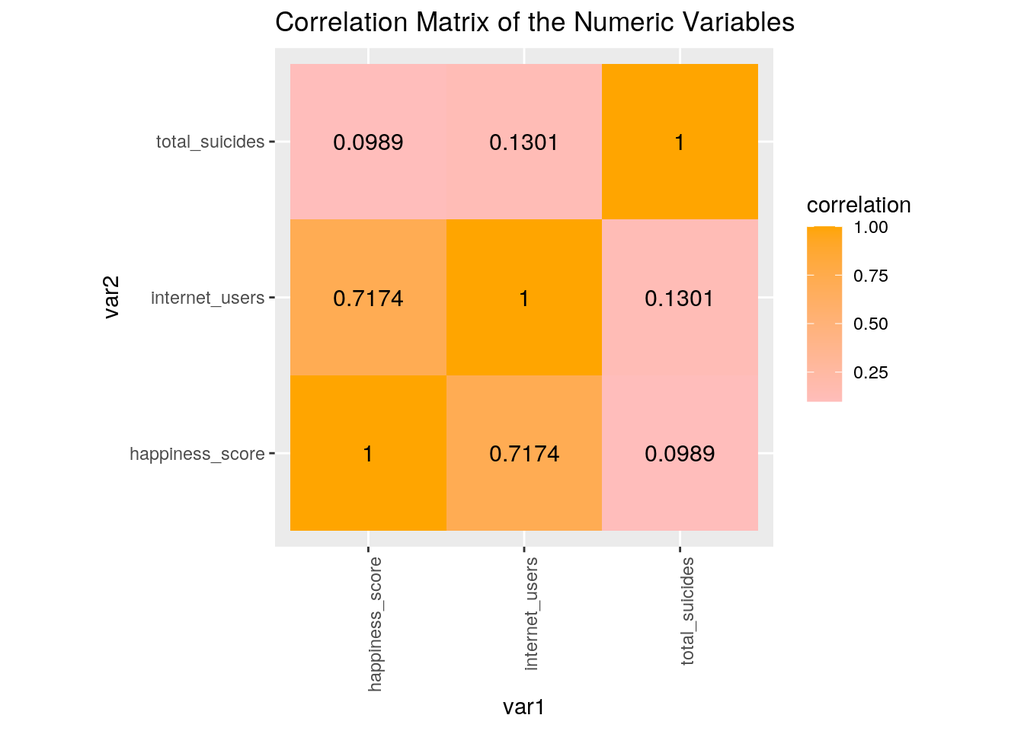

```r
variablecor %>%
  ggplot(aes(var1,var2,fill=correlation)) +
  geom_tile() +
  scale_fill_gradient2(mid="pink",high="orange") +
  geom_text(aes(label=round(correlation,4)),color = "black", size = 4) +
  theme(axis.text.x = element_text(angle = 90, hjust=1)) +
  coord_fixed() +
  labs(title="Correlation Matrix of the Numeric Variables")
```

#### *Histogram of Mean Happiness Score for Each Year from 2005 to 2015*

##### This graph shows how the mean happiness score for all of the countries changed across the years from 2005 to 2015. The mean happiness score seems to have stayed pretty consistent across the 11 years observed. The happiest year across the world in this time period seems to be 2009 while the least happy was 2005.

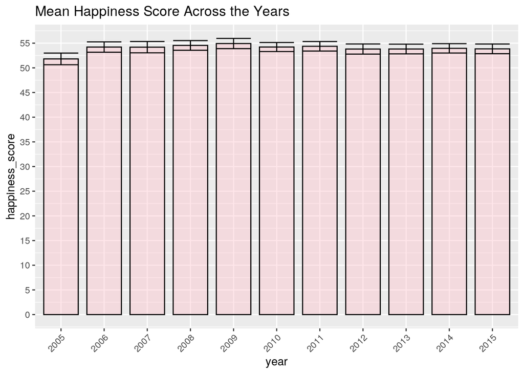

```r
completejoin %>% ggplot(aes(year,happiness_score))+
                geom_histogram(stat="summary",fun=mean,color="black",fill="pink",alpha=.4,width=.8)+
                geom_errorbar(stat="summary",fun.data=mean_se,width=.8) +
                theme(axis.text.x = element_text(angle=45, hjust=1)) +
                scale_y_continuous(n.breaks=12)+
                labs(title= "Mean Happiness Score Across the Years")
```

#### *Scatterplot of Internet Users vs. Happiness Score*

##### This plot depicts the linear relationship between internet use and the happiness scores reported. This plot also depicts the overall positive correlation/linear relationship between these two variables showing that as the internet is used more, the happier the population as a whole seems to be. This linear relationship seems to flatten out somewhat around 50% population internet use and then becomes more strongly linear again (as representd by the geom_smooth trendline).

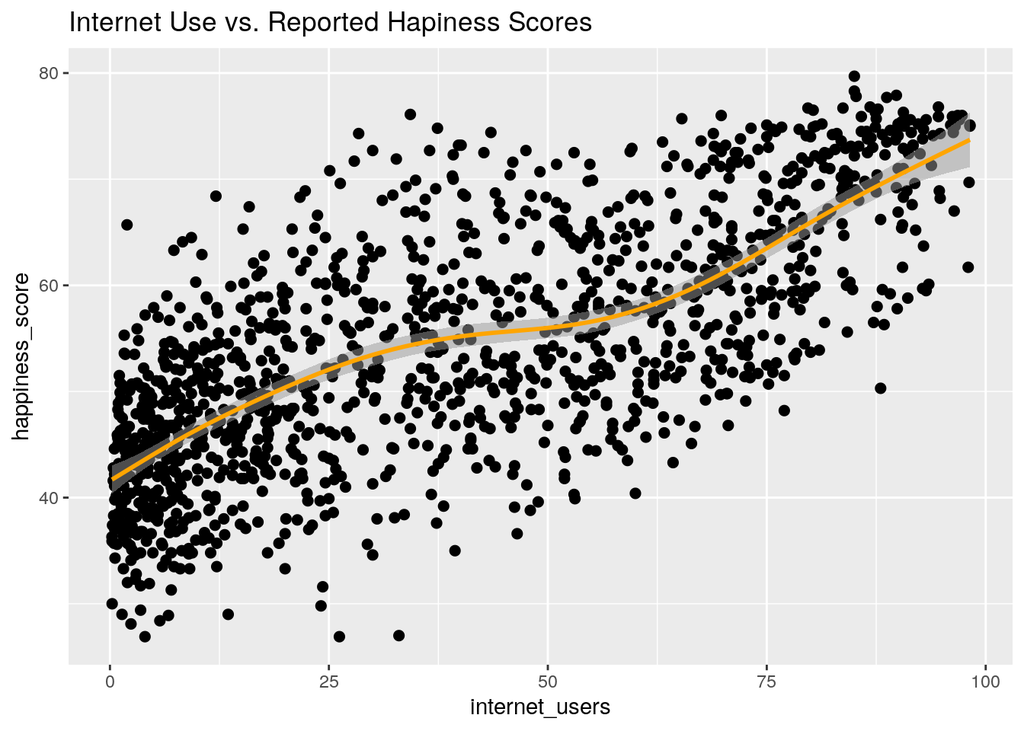

```r
completejoin %>%
  ggplot(aes(internet_users,happiness_score)) +
  geom_point(size=2) +
  geom_jitter() +
  geom_smooth(alpha=.5,color="orange") +
  labs(title="Internet Use vs. Reported Hapiness Scores")
```